# Meeting 4 Analysis Script and Plotting

Kenzie Nguyen

2025-07-10

```r
### Load in the data ###

data <- read.csv("Meeting 2 Processed Data.csv")

# Recode variable

data$PIN <- as.factor(data$PIN) # Discrete categories
data$gender <- as.factor(data$gender)
data$shock_cause <- as.factor(data$shock_cause)
data$shock <- as.factor(data$shock)
data$moral <- as.factor(data$moral)
```

## Descriptives

Descriptive statistics for guilt:

```r
c(summary(data$guilt),"SD" = sd(data$guilt, na.rm = T)) # remove NA
```

```
##     Min.  1st Qu.   Median     Mean  3rd Qu.     Max.     NA's       SD
## 1.000000 3.000000 4.000000 3.998601 5.000000 7.000000 5.000000 1.280646
```

Descriptive statistics for generosity:

```r
# Pre-shock
c(summary(data$preShare),"SD" = sd(data$preShare, na.rm = T)) # remove NA
```

```
##     Min.  1st Qu.   Median     Mean  3rd Qu.     Max.       SD
## 1.000000 3.000000 4.000000 3.979167 5.000000 7.000000 1.036663
```

```r
# Post-shock
c(summary(data$postShare),"SD" = sd(data$postShare, na.rm = T)) # remove NA
```

```
##      Min.   1st Qu.    Median      Mean   3rd Qu.      Max.        SD
##  0.000000  2.000000  4.000000  4.272222  6.000000 10.000000  2.531758
```

Descriptive statistics for personality:

```r
# Agreeableness
c(summary(data$agree),"SD" = sd(data$agree, na.rm = T)) # remove NA
```

```
##     Min.  1st Qu.   Median     Mean  3rd Qu.     Max.       SD
## 1.000000 3.000000 4.000000 3.903472 4.500000 7.000000 1.131507
```

```r
# Neuroticism
c(summary(data$neuro),"SD" = sd(data$neuro, na.rm = T)) # remove NA
```

```
##     Min.  1st Qu.   Median     Mean  3rd Qu.     Max.       SD
## 1.000000 3.000000 3.500000 3.738889 4.500000 7.000000 1.006869
```

## Guilt Analysis

### Predicition 1.1

We expected people would feel more guilt when they caused the shock vs. their partner.

This prediction was supported. People felt guilt when they caused a shock to their partner.

```r
# Run the t-test for prediction 1.1
p1.1 <- t.test(data$guilt ~ data$shock_cause)

#Output the result
p1.1
```

```
##
##  Welch Two Sample t-test
##
## data:  data$guilt by data$shock_cause
## t = -11.016, df = 708.25, p-value < 2.2e-16
## alternative hypothesis: true difference in means between group 0 and group 1 is not equal to 0
## 95 percent confidence interval:
##  -1.1502070 -0.8022365
## sample estimates:
## mean in group 0 mean in group 1
##        3.511173        4.487395
```

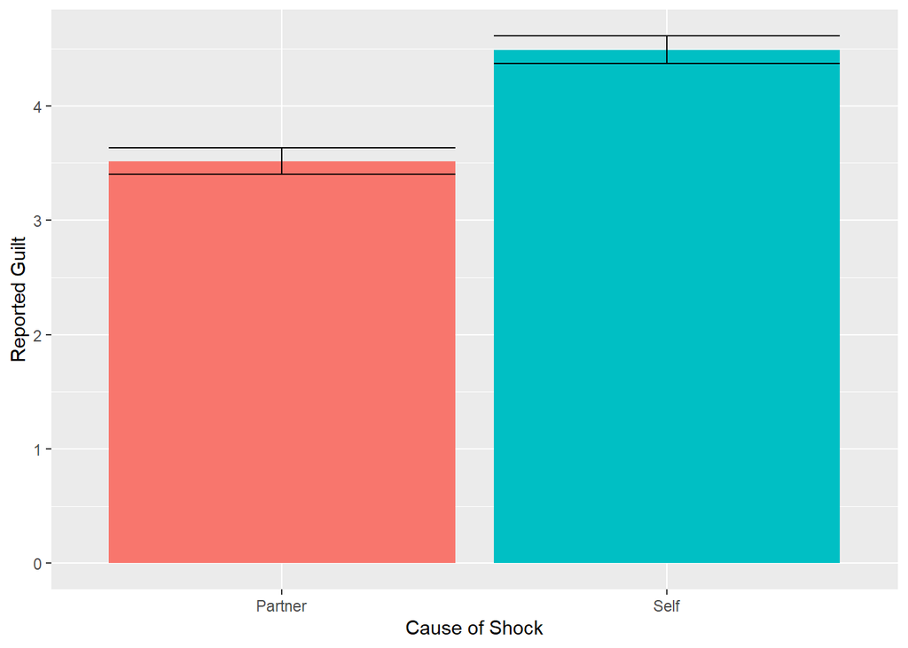

```r
# Plotting a bar plot for prediction 1.1
plot1.1 <- ggplot(data = data,
                   aes(x = shock_cause,
                       y = guilt,
                       fill = shock_cause)) + # how you set varying colors for volume geoms
  labs(x = "Cause of Shock",
       y = "Reported Guilt") +
  scale_x_discrete(labels = c("Partner", "Self")) +
  stat_summary(fun = "mean",
               geom = "bar",
               position = "dodge") + # prevents stacking
  stat_summary(fun.data = "mean_cl_boot",
               geom = "errorbar",
               position = "dodge"
               ) +
  guides(fill = F)
plot1.1
```

There was a significant difference between the two means, **t** = -11.0160769

### Predicition 1.2

We expected that people would feel more guilt when their partner was morally good vs. morally bad.

This prediction was supported. people felt more guilt their partner was morally good.

```r
# Run the t-test for prediction 1.1
p1.2 <- t.test(data$guilt ~ data$moral)

#Output the result
p1.2
```

```
##
##  Welch Two Sample t-test
##
## data:  data$guilt by data$moral
## t = -19.802, df = 707.28, p-value < 2.2e-16
## alternative hypothesis: true difference in means between group 0 and group 1 is not equal to 0
## 95 percent confidence interval:
##  -1.675632 -1.373333
## sample estimates:
## mean in group 0 mean in group 1
##        3.235294        4.759777
```

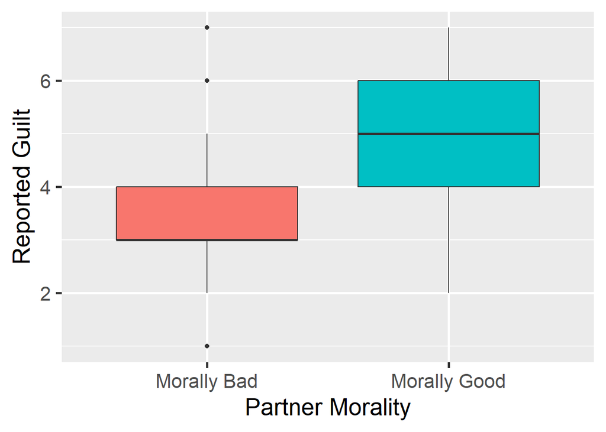

```r
# Plotting a box plot for prediction 1.2
plot1.2 <- ggplot(data = data,
                   aes(x = moral,
                       y = guilt,
                       fill = moral)) + # how you set varying colors for volume geoms
  labs(x = "Partner Morality",
       y = "Reported Guilt") +
  scale_x_discrete(labels = c("Morally Bad", "Morally Good")) +
  geom_boxplot() +
  theme_gray(base_size = 20) +
  guides(fill = F)

plot1.2
```

### Predicition 1.3

We expected that people would feel more guilt when the partner received a stronger shock.

This prediction was supported. Guilt increased with the increasing shock magnitude. There is some increase between the different categories.

```r
# Run the ANOVA for prediction 1.3
p1.3 <- lm(guilt ~ shock, data=data) # lm = linear model, ANOVA

# Output the result
anova(p1.3)
```

```
## Analysis of Variance Table
##
## Response: guilt
##            Df Sum Sq Mean Sq F value    Pr(>F)
## shock       2 193.85  96.927  70.626 < 2.2e-16 ***
## Residuals 712 977.14   1.372
## ---
## Signif. codes:  0 '***' 0.001 '**' 0.01 '*' 0.05 '.' 0.1 ' ' 1
```

```r
# Output the group means
tapply(data$guilt, data$shock, function(x) mean(x, na.rm = T))
```

```
##        0        1        2
## 3.350211 4.012605 4.625000
```

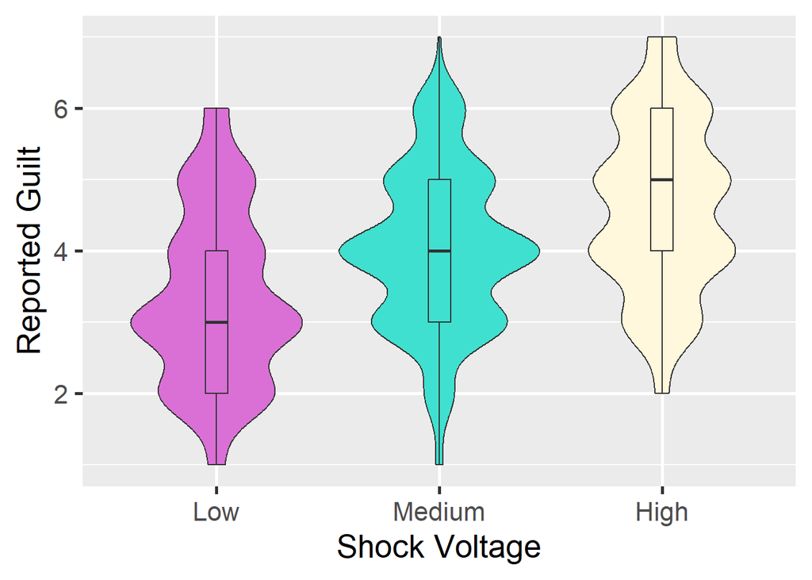

```r
# Plotting a box plot for prediction 1.3
plot1.3 <- ggplot(data = data,
                   aes(x = shock,
                       y = guilt,
                       fill = shock)) + # how you set varying colors for volume geoms
  labs(x = "Shock Voltage",
       y = "Reported Guilt") +
  scale_x_discrete(labels = c("Low", "Medium", "High")) +
  geom_violin() +
  geom_boxplot(width = 0.1) +
  theme_gray(base_size = 20) +
  guides(fill = F) +
  scale_fill_manual(values = c("orchid", "turquoise", "cornsilk"))

plot1.3
```

### Prediction 2

We expected that women will feel more guilt than men.

In spite of prior expectations, our prediction was not supported. There was no significant difference in guilt between men and women.

```r
# Run the t-test for prediction 1.1
p2 <- t.test(data$guilt ~ data$gender)

#Output the result
p2
```

```
##
##  Welch Two Sample t-test
##
## data:  data$guilt by data$gender
## t = 0.61306, df = 711.59, p-value = 0.54
## alternative hypothesis: true difference in means between group 0 and group 1 is not equal to 0
## 95 percent confidence interval:
##  -0.1293834  0.2468740
## sample estimates:
## mean in group 0 mean in group 1
##        4.027933        3.969188
```

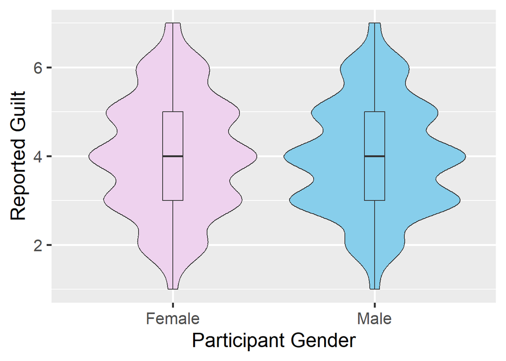

```r
# Plotting a violin plot for prediction 2
plot2 <- ggplot(data = data,
                   aes(x = gender,
                       y = guilt,
                       fill = gender)) + # how you set varying colors for volume geoms
  labs(x = "Participant Gender",
       y = "Reported Guilt") +
  scale_x_discrete(labels = c("Female", "Male")) +
  geom_violin() +
  geom_boxplot(width = 0.1) +
  theme_gray(base_size = 20) +
  guides(fill = F) +
  scale_fill_manual(values = c("thistle2", "skyblue"))

plot2
```

### Predicition 3

We expected agreeable people would report more guilt.

This prediction was supported. Agreeableness was weakly, yet significantly correlated with reported levels of guilt.

```r
# Run the correlation test for prediction 3
p3 <- cor.test(data$agree, data$guilt)

#Output the result
p3
```

```
##
##  Pearson's product-moment correlation
##
## data:  data$agree and data$guilt
## t = 4.3382, df = 713, p-value = 1.644e-05
## alternative hypothesis: true correlation is not equal to 0
## 95 percent confidence interval:
##  0.08807907 0.23096956
## sample estimates:
##       cor
## 0.1603644
```

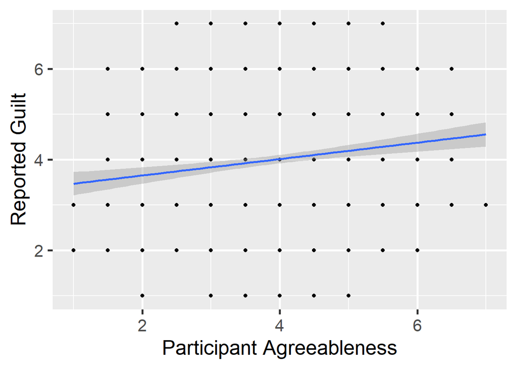

```r
# Plotting a scatter plot for prediction 3
plot3 <- ggplot(data = data,
                   aes(x = agree,
                       y = guilt,)) +
  labs(x = "Participant Agreeableness",
       y = "Reported Guilt") +
  theme_gray(base_size = 20) +
  geom_point() +
  geom_smooth(method="lm")

plot3
```

### Predicition 4

We expected neurotic people would report more guilt.

This prediction was not supported. There was no relationship between neuroticism and guilt.

```r
# Run the correlation test for prediction 4
p4 <- cor.test(data$neuro, data$guilt)

#Output the result
p4
```

```
##
##  Pearson's product-moment correlation
##
## data:  data$neuro and data$guilt
## t = -0.10897, df = 713, p-value = 0.9133
## alternative hypothesis: true correlation is not equal to 0
## 95 percent confidence interval:
##  -0.07737873  0.06926072
## sample estimates:
##         cor
## -0.00408094
```

```r
# Create a regression analysis of both neuro and agree as predictors for guilt
guilt_reg <- lm(guilt ~ neuro + agree, data=data)

# linear model is the same as ANOVA and regression. Regression slope shows a similar positive/negative relationship as correlation

# Output regression result
summary(guilt_reg)
```

```
##
## Call:
## lm(formula = guilt ~ neuro + agree, data = data)
##
## Residuals:
##     Min      1Q  Median      3Q     Max
## -3.1970 -0.9266 -0.0161  0.8942  3.2547
##
## Coefficients:
##               Estimate Std. Error t value Pr(>|t|)
## (Intercept)  3.2939882  0.2469202  13.340  < 2e-16 ***
## neuro       -0.0004411  0.0469905  -0.009    0.993
## agree        0.1809629  0.0417565   4.334 1.68e-05 ***
## ---
## Signif. codes:  0 '***' 0.001 '**' 0.01 '*' 0.05 '.' 0.1 ' ' 1
##
## Residual standard error: 1.266 on 712 degrees of freedom
##   (5 observations deleted due to missingness)
## Multiple R-squared:  0.02572,    Adjusted R-squared:  0.02298
## F-statistic: 9.397 on 2 and 712 DF,  p-value: 9.374e-05
```

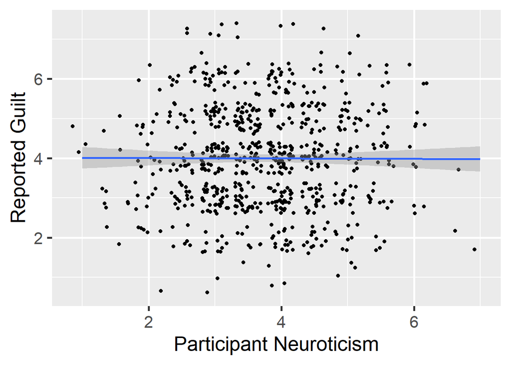

```r
# Plotting a scatter plot for prediction 4
plot4 <- ggplot(data = data,
                   aes(x = neuro,
                       y = guilt,)) +
  labs(x = "Participant Neuroticism",
       y = "Reported Guilt") +
  theme_gray(base_size = 20) +
  geom_jitter() + # jitter the points to show frequency
  geom_smooth(method="lm")

plot4
```

## Generosity

```r
# Melt the data for within-subjects analysis

data_melt <- melt(data,
                  measure.vars = c("preShare", "postShare"),
                  variable.name = c("pre_post"),
                  value.name = c("share")
     )
```

### Predicition 5.1

We expected that people would be more generous when they caused the shock vs. when the partner caused the shock to themselves.

This prediction was supported. Participants were more generous to their partner after the shock when the participant thought they were responsible for the shock.

```r
# Perform the within-subjects ANOVA for prediction 5.1
p5.1 <- aov(share ~ shock_cause*pre_post + Error(PIN), data=data_melt)

# Output the ANOVA results:
summary(p5.1)
```

```
##
## Error: PIN
##              Df Sum Sq Mean Sq F value Pr(>F)
## shock_cause   1  601.9   601.9   156.5 <2e-16 ***
## Residuals   718 2761.8     3.8
## ---
## Signif. codes:  0 '***' 0.001 '**' 0.01 '*' 0.05 '.' 0.1 ' ' 1
##
## Error: Within
##                       Df Sum Sq Mean Sq F value  Pr(>F)
## pre_post               1   30.9    30.9   14.96 0.00012 ***
## shock_cause:pre_post   1  534.1   534.1  258.51 < 2e-16 ***
## Residuals            718 1483.5     2.1
## ---
## Signif. codes:  0 '***' 0.001 '**' 0.01 '*' 0.05 '.' 0.1 ' ' 1
```

```r
# Output the means separated by conditions
tapply(data_melt$share, data_melt[, c("shock_cause", "pre_post")],
       function(x) mean(x, na.rm = T))
```

```
##            pre_post
## shock_cause preShare postShare
##           0 3.941667  3.016667
##           1 4.016667  5.527778
```

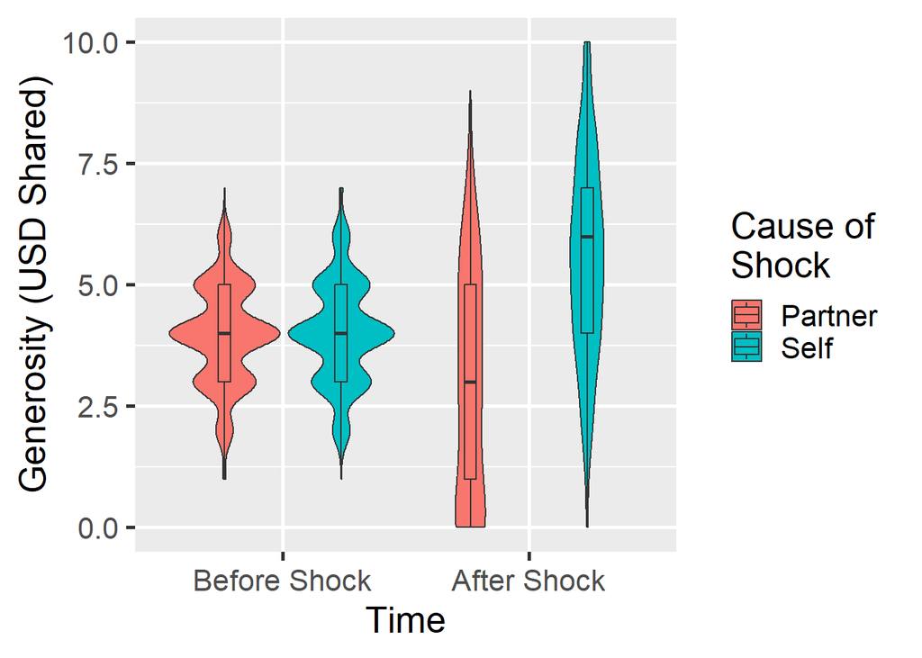

```r
# Plotting for prediction 5.1
plot5.1 <- ggplot(data = data_melt,
                   aes(x = pre_post,
                       y = share,
                       fill = shock_cause)) +
  labs(x = "Time",
       y = "Generosity (USD Shared)",
       fill = "Cause of \nShock") +  # line break
  theme_gray(base_size = 20) +
  geom_violin(position = position_dodge(0.95)) +
  geom_boxplot(position = position_dodge(0.95), width = 0.1) +
  scale_x_discrete(labels = c("Before Shock", "After Shock")) +
  scale_fill_discrete(labels = c("Partner", "Self"))

plot5.1
```

### Prediction 5.2

We expected that people would be more generous when their partner was morally good vs. morally bad.

This prediction was supported. Participants were more generous to their morally good partner after the shock.

```r
# Perform the within-subjects ANOVA for prediction 5.1
p5.2 <- aov(share ~ moral*pre_post + Error(PIN), data=data_melt)

# Output the ANOVA results:
summary(p5.2)
```

```
##
## Error: PIN
##            Df Sum Sq Mean Sq F value Pr(>F)
## moral       1  872.7   872.7   251.5 <2e-16 ***
## Residuals 718 2491.1     3.5
## ---
## Signif. codes:  0 '***' 0.001 '**' 0.01 '*' 0.05 '.' 0.1 ' ' 1
##
## Error: Within
##                 Df Sum Sq Mean Sq F value   Pr(>F)
## pre_post         1   30.9    30.9   22.52 2.51e-06 ***
## moral:pre_post   1 1031.9  1031.9  751.69  < 2e-16 ***
## Residuals      718  985.7     1.4
## ---
## Signif. codes:  0 '***' 0.001 '**' 0.01 '*' 0.05 '.' 0.1 ' ' 1
```

```r
# Output the means separated by conditions
tapply(data_melt$share, data_melt[, c("moral", "pre_post")],
       function(x) mean(x, na.rm = T))
```

```
##      pre_post
## moral preShare postShare
##     0 4.047222  2.647222
##     1 3.911111  5.897222
```

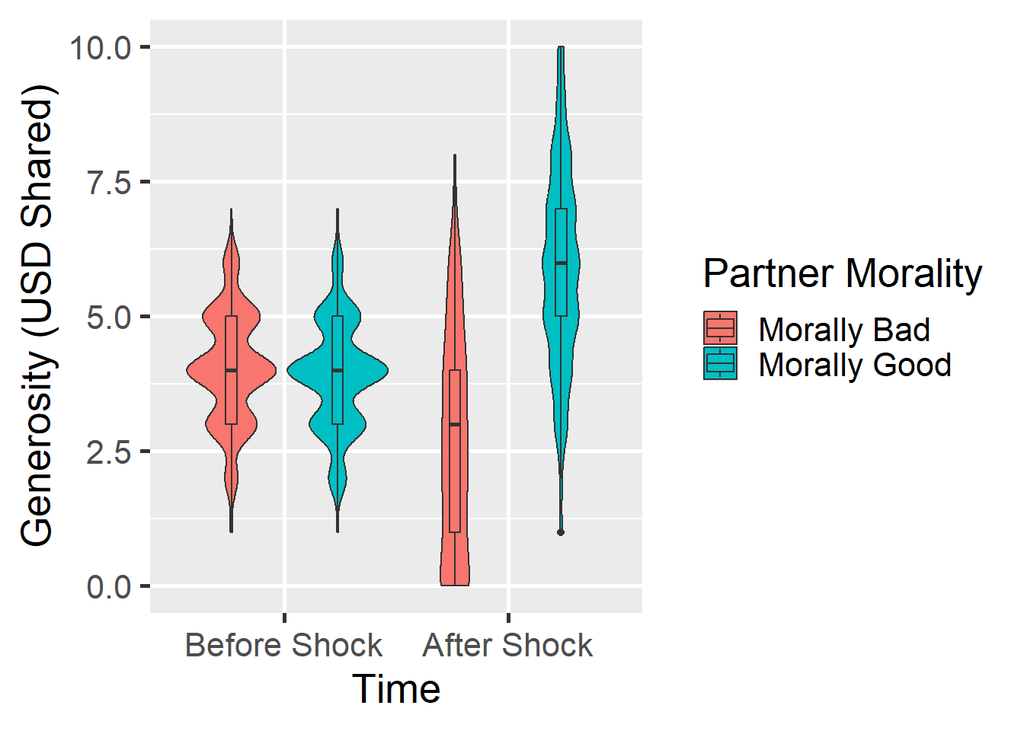

```r
# Plotting for prediction 5.2
plot5.2 <- ggplot(data = data_melt,
                   aes(x = pre_post,
                       y = share,
                       fill = moral)) +
  labs(x = "Time",
       y = "Generosity (USD Shared)",
       fill = "Partner Morality") +  # line break
  theme_gray(base_size = 20) +
  geom_violin(position = position_dodge(0.95)) +
  geom_boxplot(position = position_dodge(0.95), width = 0.1) +
  scale_x_discrete(labels = c("Before Shock", "After Shock")) +
  scale_fill_discrete(labels = c("Morally Bad", "Morally Good"))

plot5.2
```

### Predicition 5.3

We expected that people would be more generous when the shock was stronger.

This prediction was supported. Pre-shock there was no difference in generosity, but generosity tracks level of shock

```r
# Perform the within-subjects ANOVA for prediction 5.1
p5.3 <- aov(share ~ shock*pre_post + Error(PIN), data=data_melt)

# Output the ANOVA results:
summary(p5.3)
```

```
##
## Error: PIN
##            Df Sum Sq Mean Sq F value   Pr(>F)
## shock       2  277.4   138.7   32.23 3.97e-14 ***
## Residuals 717 3086.3     4.3
## ---
## Signif. codes:  0 '***' 0.001 '**' 0.01 '*' 0.05 '.' 0.1 ' ' 1
##
## Error: Within
##                 Df Sum Sq Mean Sq F value   Pr(>F)
## pre_post         1   30.9   30.92   12.32 0.000476 ***
## shock:pre_post   2  218.5  109.25   43.54  < 2e-16 ***
## Residuals      717 1799.1    2.51
## ---
## Signif. codes:  0 '***' 0.001 '**' 0.01 '*' 0.05 '.' 0.1 ' ' 1
```

```r
# Output the means separated by conditions
tapply(data_melt$share, data_melt[, c("shock", "pre_post")],
       function(x) mean(x, na.rm = T))
```

```
##      pre_post
## shock preShare postShare
##     0 3.891667  3.233333
##     1 4.037500  4.325000
##     2 4.008333  5.258333
```

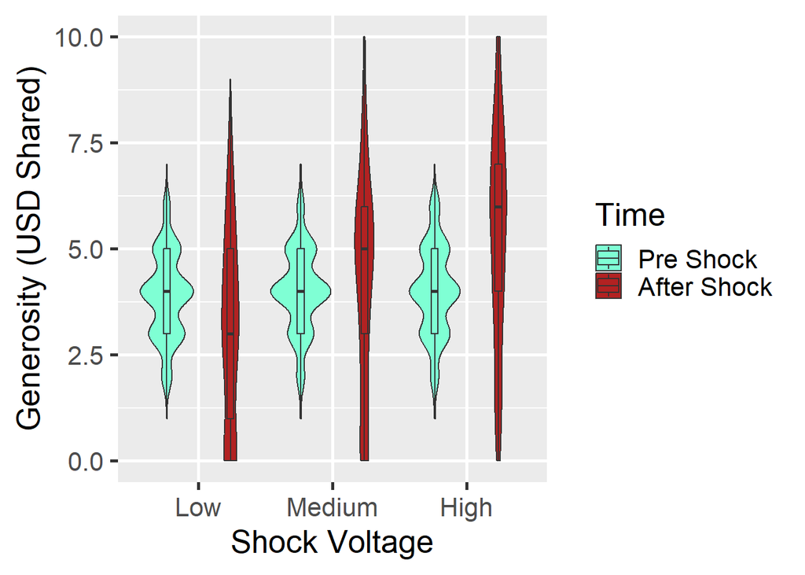

```r
# Plotting for prediction 5.2
plot5.3 <- ggplot(data = data_melt,
                   aes(x = shock,
                       y = share,
                       fill = pre_post)) +
  labs(x = "Shock Voltage",
       y = "Generosity (USD Shared)",
       fill = "Time") +  # line break
  theme_gray(base_size = 20) +
  geom_violin(position = position_dodge(0.95)) +
  geom_boxplot(position = position_dodge(0.95), width = 0.1) +
  scale_x_discrete(labels = c("Low", "Medium", "High")) +
  scale_fill_manual(labels = c("Pre Shock", "After Shock"),
                    values = c("aquamarine", "firebrick"))

plot5.3
```

### Predicition 6

We expected that women would be more generous than men.

This prediction was not supported. There was not a significant interaction between gender and generosity.

```r
# Perform the within-subjects ANOVA for prediction 5.1
p6 <- aov(share ~ gender*pre_post + Error(PIN), data=data_melt)

# Output the ANOVA results:
summary(p6)
```

```
##
## Error: PIN
##            Df Sum Sq Mean Sq F value Pr(>F)
## gender      1      0   0.001       0   0.99
## Residuals 718   3364   4.685
##
## Error: Within
##                  Df Sum Sq Mean Sq F value   Pr(>F)
## pre_post          1   30.9  30.917   11.00 0.000955 ***
## gender:pre_post   1    0.1   0.084    0.03 0.862756
## Residuals       718 2017.5   2.810
## ---
## Signif. codes:  0 '***' 0.001 '**' 0.01 '*' 0.05 '.' 0.1 ' ' 1
```

```r
# Output the means separated by conditions
tapply(data_melt$share, data_melt[, c("gender", "pre_post")],
       function(x) mean(x, na.rm = T))
```

```
##       pre_post
## gender preShare postShare
##      0 3.972222  4.280556
##      1 3.986111  4.263889
```

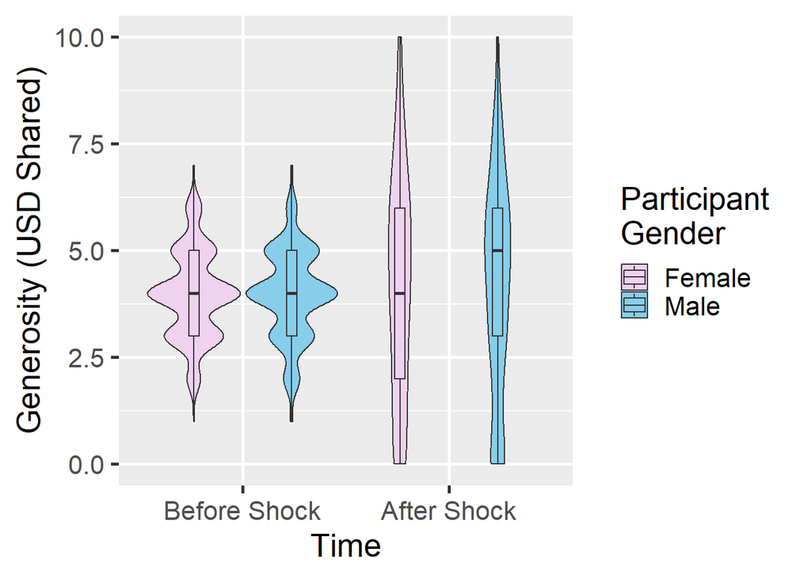

```r
# Plotting for prediction 6
plot6 <- ggplot(data = data_melt,
                   aes(x = pre_post,
                       y = share,
                       fill = gender)) +
  labs(x = "Time",
       y = "Generosity (USD Shared)",
       fill = "Participant \nGender") +  # line break
  theme_gray(base_size = 20) +
  geom_violin(position = position_dodge(0.95)) +
  geom_boxplot(position = position_dodge(0.95), width = 0.1) +
  scale_x_discrete(labels = c("Before Shock", "After Shock")) +
  scale_fill_manual(labels = c("Female", "Male"),
                    values = c("thistle2", "skyblue"))

plot6
```

### Predicition 7

We expected that agreeable people would be more generous than disagreeable people.

This prediction was partially supported. Agreeable people were more generous after the shock but not before.

```r
# Perform correlation test for pre shock generosity
p7pre <- cor.test(data$preShare, data$agree)

# Output the results
p7pre
```

```
##
##  Pearson's product-moment correlation
##
## data:  data$preShare and data$agree
## t = -1.7335, df = 718, p-value = 0.08343
## alternative hypothesis: true correlation is not equal to 0
## 95 percent confidence interval:
##  -0.13697875  0.00854694
## sample estimates:
##         cor
## -0.06455913
```

```r
# Perform correlation test for post shock generosity
p7post <- cor.test(data$postShare, data$agree)

# Output the results
p7post
```

```
##
##  Pearson's product-moment correlation
##
## data:  data$postShare and data$agree
## t = 2.9172, df = 718, p-value = 0.003643
## alternative hypothesis: true correlation is not equal to 0
## 95 percent confidence interval:
##  0.03544253 0.17987139
## sample estimates:
##      cor
## 0.108228
```

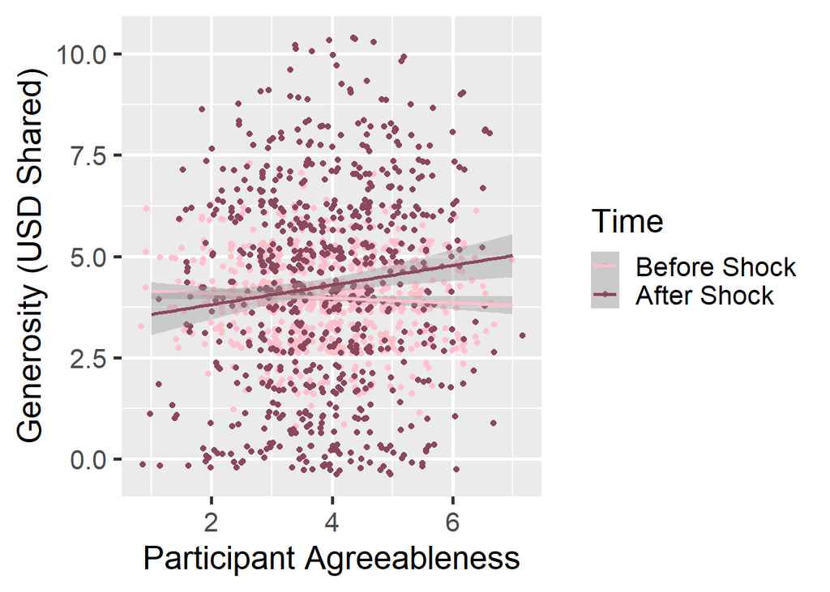

```r
# Plotting for prediction 7
plot7 <- ggplot(data = data_melt,
                   aes(x = agree,
                       y = share,
                       color = pre_post)) +
  labs(x = "Participant Agreeableness",
       y = "Generosity (USD Shared)",
       color = "Time") +
  theme_gray(base_size = 20) +
  geom_jitter() + # jitter the points to show frequency
  geom_smooth(method="lm") +
  scale_color_manual(labels = c("Before Shock", "After Shock"),
                     values = c("pink", "palevioletred4"))

plot7
```

### Predicition 8

We expected that neurotic people would be more generous than emotionally stable people.

This prediction was not supported. There is no correlation between neuroticism and generosity before or after the shock.

```r
# Perform correlation test for pre shock generosity
p8pre <- cor.test(data$preShare, data$neuro)

# Output the results
p8pre
```

```
##
##  Pearson's product-moment correlation
##
## data:  data$preShare and data$neuro
## t = -0.60415, df = 718, p-value = 0.5459
## alternative hypothesis: true correlation is not equal to 0
## 95 percent confidence interval:
##  -0.09544967  0.05060798
## sample estimates:
##         cor
## -0.02254112
```

```r
# Perform correlation test for post shock generosity
p8post <- cor.test(data$postShare, data$neuro)

# Output the results
p8post
```

```
##
##  Pearson's product-moment correlation
##
## data:  data$postShare and data$neuro
## t = -0.09243, df = 718, p-value = 0.9264
## alternative hypothesis: true correlation is not equal to 0
## 95 percent confidence interval:
##  -0.07649589  0.06963389
## sample estimates:
##          cor
## -0.003449418
```

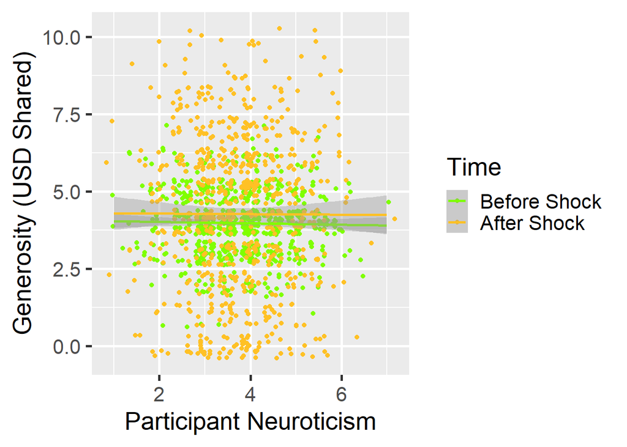

```r
# Plotting for prediction 8
plot8 <- ggplot(data = data_melt,
                   aes(x = neuro,
                       y = share,
                       color = pre_post)) +
  labs(x = "Participant Neuroticism",
       y = "Generosity (USD Shared)",
       color = "Time") +
  theme_gray(base_size = 20) +
  geom_jitter() + # jitter the points to show frequency
  geom_smooth(method="lm") +
  scale_color_manual(labels = c("Before Shock", "After Shock"),
                     values = c("chartreuse", "goldenrod1"))

plot8
```